# New York City Car Collision Data Analysis

Nicholas Esposito

5/10/2021

#Set Page/Margin Format

#Load Libraries

# Introduction

Globally, road accidents are the major cause of fatalities and injuries. Statistical chances of dying in a plane crash are 1 in 9,821, while death by car are statically more probable, at 1 in 114.

Analysis of car crash data has been and can be used as a basis for highway and vehicle designs safety systems, and support local authorities in allocating resources aimed at improving road safety and making decisions to mitigate road risks in the most exposed areas. In this paper, we analyze the crash report data from the City of New York to show trends and patterns in car crashes reported in and around the metro area.

The analysis is especially useful because it uses data that is updated periodically, so this study can be reproduced by reloading the updated database within R to visualize current trends.

## Statistics

By 2030, car crashes are predicted to be the 5th leading cause of death in the world according to the World Health Organization (Mannering and Bhat 2014). In the United States, traffic incidents are the first cause of workplace fatalities and the leading cause of death for children aged 1–19 (Cunningham et al. 2018).

Thus, road crashes have relevant social impacts.

## Limitations

Ideally, driving-related data (such as acceleration and braking) and crash-related data (such as those made available from vehicle black-boxes) would help to identify cause and effect relationships, but they are rarely recorded or made available to the public as is the the case in our data set. Other obscured factors tend to be driver socio-economic status, driver age, insurance premiums and other personal data. Many of these these co-variates are often proprietary and limited to some places or periods. Additional information to infer crash causes can also be obtained by mining exogenous databases or scraping the web but these indicators are not readily available to us in the context of New York as a whole (where our study is based).

Hence, a large majority of research has addressed the problem in terms of understanding the factors that affect the frequency of crashes after the fact, i.e. the number of crashes occurring in some geographical space over some specified time period, vehicle make and model, crash time and date, road design, sign placement etc.

Since data availability is constrained to after the crash has occurred, my predictive power maybe be limited considering means to estimate a driver’s risk of crash, for instance, it is since it is customary to use car characteristics, claims history or qualitative and quantitative information of the region where the driver lives (i.e. the population density of the postal code only some of this information is available.

I am also limited by processing power, as the dataset contains many columns each with many factors and when entered into regression may cause memory and processing delays which make trialing the data set tedious if not impossible and results may show significant heteroskedascity.

## Methodology

I will try answer specific questions or highlight important trends within the data set, using mainly visual aids in the form of plots. This approach will increase the likelihood this study will be reused for mainly visualizing exigent trends in NYC car collisions.

In this study we will assume that all entries into the database represent a car crash. Incomplete data points, for example where the cause of a crash is missing will be imputed with place holder terms such as `Unspecified’ to avoid ambiguity from NA values. This is important to visualize how much of the data we are actually able to classify and analyze.

A significant component of the data set contains time variables. While R studio is not ideal for managing dates Posixct provides a malleable option for graphing which will be used.

# Data Cleaning and Exploration

The Original data set comes from the NYC OPEN DATA, database https://data.cityofnewyork.us/Public-Safety/Motor-Vehicle-Collisions-Crashes/h9gi-nx95.

A plot of missing data within the original data set reveals that several columns of data contain vast proportions (blue) of missing data. However these columns of missing data are empty not to due error but the fact that data for that observation does not exist, for example the “CONTRIBUTING FACTOR VEHICLE 3” is empty because not every crash had a third vehicle involved.

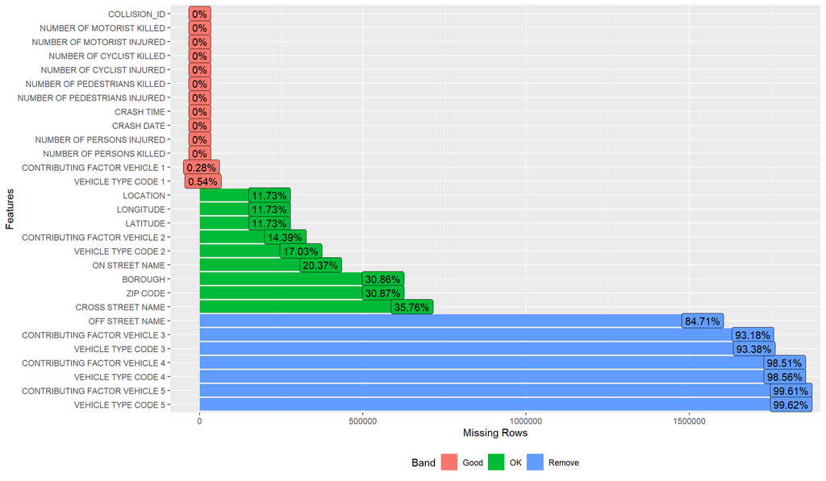

First, by removing unnecessary columns that this research does not need, and filtering by complete cases of longitudinal data and latitudinal data I created a dataset with far less missing data in it’s observations. Also by converting the remaining NA values to a character will help with linear regressions if I choose to use them. We will assume that current NA values, for example n the case of “CONTRIBUTING FACTOR VEHICLE 3” assumes that there is no 3rd vehicle associated with that crash instance.

A glimpse of the first 6 rows and 17 columns in our data set reveals cleaned data set. Note the last column where CRASH DATE and CRASH TIME have been merged to form a new column CRASH DATE AND TIME in form of a Posixct date and time format, from these values I will conduct the research.

| CRASH DATE | CRASH TIME | BOROUGH | LATITUDE | LONGITUDE | NUMBER OF PEDESTRIANS INJURED | NUMBER OF PEDESTRIANS KILLED | NUMBER OF CYCLIST INJURED | NUMBER OF CYCLIST KILLED | NUMBER OF MOTORIST INJURED | NUMBER OF MOTORIST KILLED | CONTRIBUTING FACTOR VEHICLE 1 | CONTRIBUTING FACTOR VEHICLE 2 | CONTRIBUTING FACTOR VEHICLE 3 | COLLISION_ID | VEHICLE TYPE CODE 1 | CRASH DATE AND TIME |
| --- | --- | --- | --- | --- | --- | --- | --- | --- | --- | --- | --- | --- | --- | --- | --- | --- |
| 04/13/2021 | 21:35:00 | BROOKLYN | 40.68358 | -73.97617 | 1 | 0 | 0 | 0 | 0 | 0 | Unspecified | No second vehicle | No third vehicle | 4407147 | Sedan | 2021-04-13 21:35:00 |
| 04/12/2021 | 08:25:00 | Unknown Borough | 0.00000 | 0.00000 | 0 | 0 | 0 | 0 | 0 | 0 | Unspecified | Unspecified | No third vehicle | 4406885 | Station Wagon/Sport Utility Vehicle | 2021-04-12 08:25:00 |
| 05/21/2019 | 22:50:00 | BROOKLYN | 40.69754 | -73.98312 | 0 | 0 | 0 | 0 | 0 | 0 | Passing or Lane Usage Improper | Unspecified | No third vehicle | 4136992 | MBU | 2019-05-21 22:50:00 |
| 02/26/2021 | 14:50:00 | BRONX | 40.84346 | -73.83600 | 0 | 0 | 0 | 0 | 0 | 0 | Unspecified | Unspecified | No third vehicle | 4395664 | Station Wagon/Sport Utility Vehicle | 2021-02-26 14:50:00 |
| 03/09/2021 | 11:00:00 | Unknown Borough | 40.69255 | -73.99097 | 0 | 0 | 0 | 0 | 1 | 0 | Following Too Closely | Unspecified | No third vehicle | 4397513 | Pick-up Truck | 2021-03-09 11:00:00 |
| 03/31/2021 | 22:20:00 | BROOKLYN | 40.62646 | -73.91800 | 0 | 0 | 0 | 0 | 1 | 0 | Driver Inexperience | Unspecified | No third vehicle | 4403773 | Sedan | 2021-03-31 22:20:00 |

A brief description of our variables:

| Variable | Description |
| --- | --- |
| CRASH DATE | Date of the incident |
| CRASH TIME | Hour and minute time stamp of the incident |
| BOROUGH | One of Five Boroughs Including Manhattan, Bronx, Queens, Brooklyn, Staten Island |
| LATITUDE | Latitude Coordinates |
| LONGITUDE | Longitude Coordinates |
| NUMBER OF PEDESTRIANS INJURED | Pedestrians injured in the crash |
| NUMBER OF PEDESTRIANS KILLED | Pedestrians killed in the crash |
| NUMBER OF CYCLIST INJURED | Cyclists injured in the the crash |
| NUMBER OF CYCLIST KILLED | Cyclists killed in the crash |
| NUMBER OF MOTORIST INJURED | Motorists injured in the crash |
| NUMBER OF MOTORIST KILLED | Motorists killed in the crash |
| CONTRIBUTING FACTOR VEHICLE 1 | The factor that caused the crash in the initial vehicle |
| CONTRIBUTING FACTOR VEHICLE 2 | The factor that caused the crash in the second vehicle *if multi-car crash |
| CONTRIBUTING FACTOR VEHICLE 3 | The factor that caused the crash in the third vehicle *if multi-car crash |
| COLLISION_ID | Unique individual crash ID |
| VEHICLE TYPE CODE 1 | Vehicle designation |
| Crash Date and Crash Time | Crash date and time in combined entry |

Statistical Data Summary of variables.

Summary Statistics

| Variable | N | Mean | Std. Dev. | Min | Pctl. 25 | Pctl. 75 | Max |
| --- | --- | --- | --- | --- | --- | --- | --- |
| BOROUGH | 1605282 |  |  |  |  |  |  |
| … BRONX | 176150 | 11% |  |  |  |  |  |
| … BROOKLYN | 386686 | 24.1% |  |  |  |  |  |
| … MANHATTAN | 281030 | 17.5% |  |  |  |  |  |
| … QUEENS | 329351 | 20.5% |  |  |  |  |  |
| … STATEN ISLAND | 51664 | 3.2% |  |  |  |  |  |
| … Unknown Borough | 380401 | 23.7% |  |  |  |  |  |
| LATITUDE | 1605282 | 40.675 | 1.419 | 0 | 40.668 | 40.769 | 43.344 |
| LONGITUDE | 1605282 | -73.839 | 2.777 | -201.36 | -73.976 | -73.867 | 0 |
| NUMBER OF PEDESTRIANS INJURED | 1605282 | 0.054 | 0.239 | 0 | 0 | 0 | 27 |
| NUMBER OF PEDESTRIANS KILLED | 1605282 | 0.001 | 0.027 | 0 | 0 | 0 | 6 |
| NUMBER OF CYCLIST INJURED | 1605282 | 0.025 | 0.157 | 0 | 0 | 0 | 4 |
| NUMBER OF CYCLIST KILLED | 1605282 | 0 | 0.01 | 0 | 0 | 0 | 2 |
| NUMBER OF MOTORIST INJURED | 1605282 | 0.2 | 0.631 | 0 | 0 | 0 | 43 |
| NUMBER OF MOTORIST KILLED | 1605282 | 0.001 | 0.025 | 0 | 0 | 0 | 5 |
| COLLISION_ID | 1605282 | 2991236.339 | 1501368.319 | 22 | 3057562.5 | 4017963.75 | 4455511 |

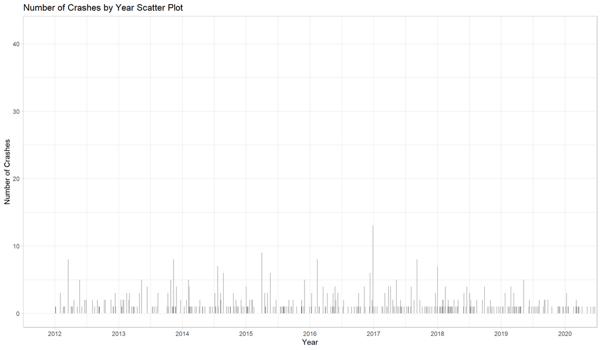

A bar plot of crashes reveals that there has been a downward trend in crashes in New York City, particularly since the start of the pandemic.

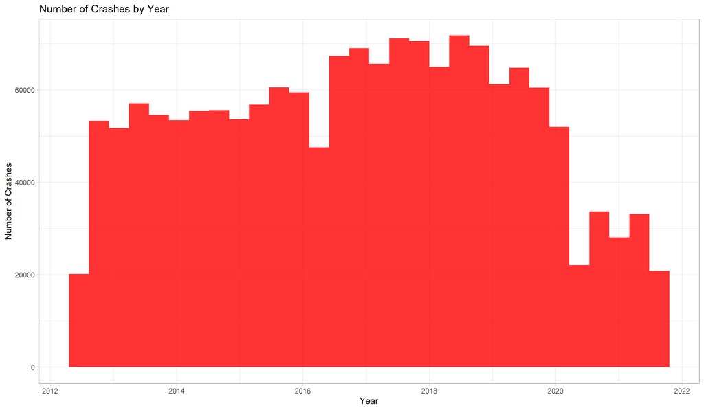

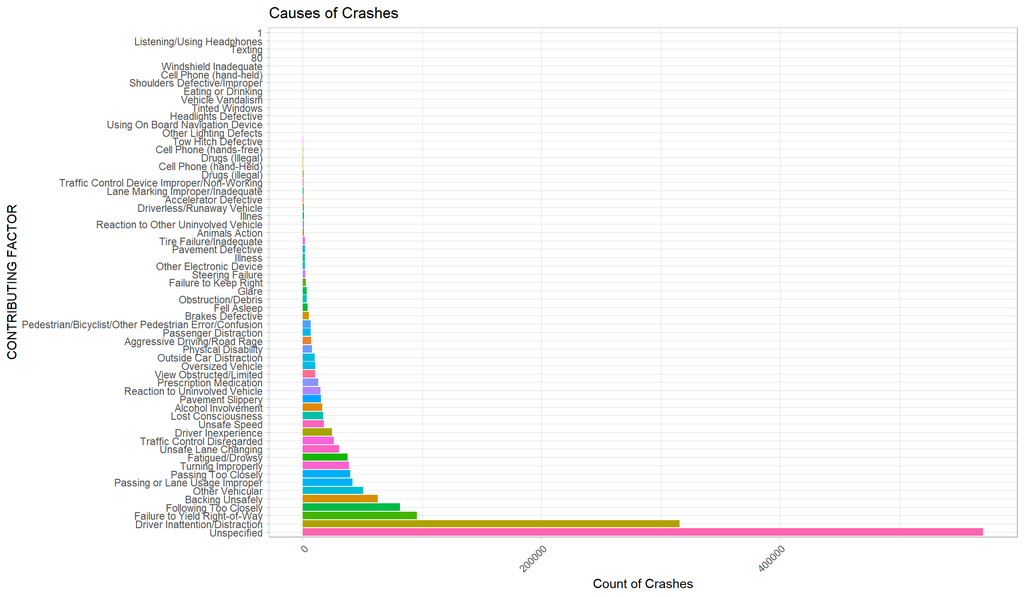

Geo spacial plots show the site of each individual crash, some freeways are noteably free from crashes, indicating drivers may become more alert on freeways given that Driver Inattention is the leading causes of crashes. The City should investigate means to increases driver attention in other settings apart from freeways to decrease overall collision occurence.

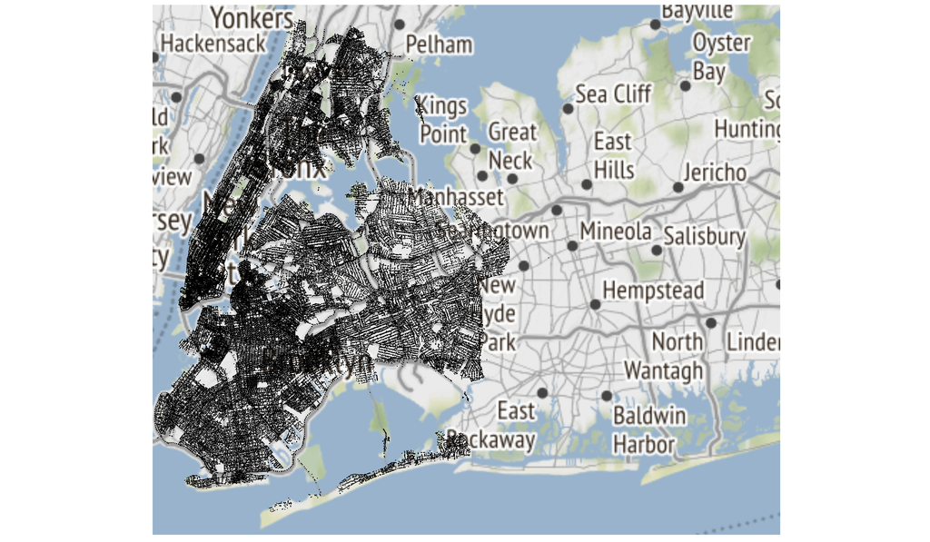

# Conclusions

Over the past decade, New York has made tremendous strides in reducing fatalities on its roadways. Data collection remains a barrier to complete analysis, as the cause of many crashes remain unspecified. While Geo-spacial analysis is possible more concrete data of urban planning lay out is required to accertain junctures that cause crashes more frequently.

# References

- Borgoni, Riccardo, et al. “Assessing the Risk of Car Crashes in Road Networks.” Social Indicators Research, vol. 156, no. 2-3, 2020, pp. 429–447., https://doi.org/10.1007/s11205-020-02295-x.
- Gayer, Ted. “The Fatality Risks of Sport-Utility Vehicles, Vans, and Pickups Relative to Cars.” Journal of Risk and Uncertainty, vol. 28, no. 2, 2004, pp. 103–133., https://doi.org/10.1023/b:risk.0000016139.79886.3e.
- Wen, Huiying, et al. “A Comprehensive Analysis for the Heterogeneous Effects on Driver Injury Severity in Single-Vehicle Passenger Car and SUV Rollover Crashes.” Journal of Advanced Transportation, vol. 2020, 2020, pp. 1–13., https://doi.org/10.1155/2020/1273605.